# In class exercise: Metropolis algorithm

# 1 Introduction

In these exercises, we will explore an powerful method of sampling from a distribution $\pi$. The algorithm we will discuss is usually referred to as the Metropolis-Hastings algorithm; Metropolis was one of the authors on the ground breaking [paper](https://en.wikipedia.org/wiki/Equation_of_State_Calculations_by_Fast_Computing_Machines) and [Hastings](https://academic.oup.com/biomet/article-abstract/107/1/1/5686745?redirectedFrom=fulltext) considered extensions to this work and applications to statistics.

The key feature is that again we construct a Markov chain that has $\pi$ as its stationary distribution, and we need only know $\pi$ up to a constant factor. The following simple exercise in Bayesian statistics may help to illustrate why this is important.

## 1.1 Exercise

Let $X=(X_1, \ldots, X_n)$ be a random sample from the conditional distribution of $X_1$ given $\Theta = \theta$, where $X_1|\theta \sim Bern(\theta)$ and $\Theta \sim Unif(0,1)$. Find the posterior distribution.

### 1.1.1 Solution

Let $x \in \{0,1\}^n$ and $t= x_1 + \cdots +x_n$. Let $\theta \in (0,1)$. Let $r(\theta) = \mathbf{1}[\theta \in (0,1)]$ be the prior pdf for $\Theta$ and $f_X$ be the pdf for $X$. We have that
$$\begin{eqnarray*}
s(\theta|x) &=& \frac{L(x|\theta)r(\theta)}{ f_X(x)} \\
&=& \frac{\theta^t (1-\theta)^{n-t}}{f_X(x)}.
\end{eqnarray*}$$
We have that
$$f_X(x) = \int_0 ^1 L(x|\theta) d\theta = \int_0 ^1 \theta^t(1-\theta)^{n-t}d \theta,$$
where we recognize that we don’t really need to compute this integral, since we recognize that this is the beta distribution, so that $s(\theta|x)$ is given by the pdf of beta distribution in $\theta$ with parameters $\alpha = t+1$ and $\beta = n-t+1$, where $t= x_1 + \cdots + x_n$.

A problem arises when we do not recognize the distribution, and the integral of $f_X$ is difficult to compute, but we still want to sample, simulate, or understand $s(\theta|x)$.

# 2 The Metropolis-Hastings algorithm

Suppose that we want to sample from $\pi(i) = \tilde{\pi}(i)/C$; in this context it is often called the *target* distribution, and we only know $\tilde{\pi}$ In the Metropolis algorithm, we choose a *symmetric* transition matrix $Q$, called the *proposal distribution* and we typically write $Q(j|i) = Q_{ij}$; it turns out than we will many choices for $Q$, and it is an active area of research on how to choose the best $Q$ with respect to convergence and robustness. Hastings generalized the Metropolis algorithm to allow from non-symmetric choices for $Q$. We consider the Markov chain which advances one step in the following way.

- If we are at a state $i$, so that $X_n=i$, then we generate a random variable $Y=j$ with distribution $Q(\cdot|i)$.
- Given that $Y=j$, we move to state $j$, so that $X_{n+1} = j$, with probability
  $$\alpha(j|i) = \min\big( \tfrac{\tilde{\pi}(j)}{\tilde{\pi}(i)} \cdot \tfrac{Q(i|j)}{Q(j|i)},1\big);$$
- Otherwise, we stay in state $i$, so that $X_{n+1} = i$.

If we do move to state $j$ the proposal is sometimes refered to as being *accepted*; we can actually have some freedom to choose $\alpha$, and the choice above is sometimes referred to as the Metropolis choice.

In order to show that this method works, we show that $\pi$ is indeed a stationary distribution for this Markov chain, and to do this, it is enough to verify that it is a reversible distribution with respect to the transition matrix, which is given by:
$$P(j|i) = Q(j|i)\alpha(j|i),$$

when $i \not = j$. We need to check that
$$\pi_{i}P(j|i) = \pi_{j} P(i|j);$$
notice that there is nothing to check if $i = j$.

## 2.1 Exercise

Check it! Note that for $a >0,$ we have $\min(a,1) =a$, then $\min(1/a, 1) =1$.

## 2.2 Exercise

Technically, we have only verified Metropolis-Hastings for a finite state space, but we also adapt the algorithm for the case of continuous distributions. Try the Metropolis algorithm, on the first exercise using by letting $Y$ be normal with mean $i$, where we let $Q(j|i)$ be the pdf of a normal distribution centered at $i$ with variance $1$. Fix $n=5$, and $t=2$.

### 2.2.1 Solution

To check reversibility, for $i \not = j$, we have

$$\begin{eqnarray*}
\pi_{i}P(j|i) &=& \pi_{i}Q(j|i)\alpha(j|i) \\
&=& \pi_{i}Q(j|i)\min\big( \tfrac{\tilde{\pi}(j)}{\tilde{\pi}(i)} \cdot \tfrac{Q(i|j)}{Q(j|i)},1\big).
\end{eqnarray*}$$

If $\min\big( \tfrac{\tilde{\pi}(j)}{\tilde{\pi}(i)} \cdot \tfrac{Q(i|j)}{Q(j|i)},1\big)=\tfrac{\tilde{\pi}(j)}{\tilde{\pi}(i)} \cdot \tfrac{Q(i|j)}{Q(j|i)}$, then

$$\begin{eqnarray*}
\pi_{i}P(j|i) &=& \pi_{i}Q(j|i) \tfrac{\tilde{\pi}(j)}{\tilde{\pi}(i)} \\
&=& \pi_j Q(j|i),
\end{eqnarray*}$$

### 2.2.2 Solution R code

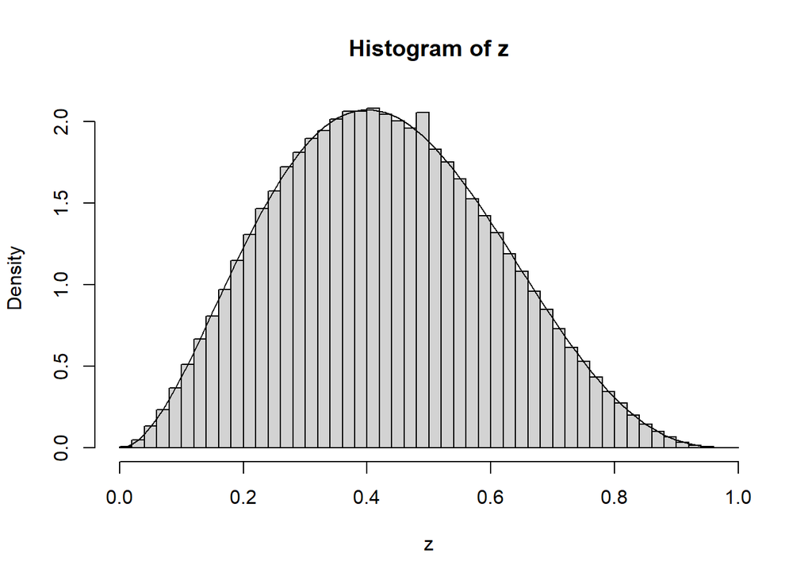

```r
h <- function(x){
 z=0
  if(x >0 && x <1 ) {z=(x^2) * ( (1-x)^3)}
 z
  }


Yq <- function(x){
   y= rnorm(1,x,1)
y
}

a <- function(j,i){
m=min( c( h(j)/h(i), 1 ))
m
}

metro <- function(n){
  x=0.5
  for(k in 1:n){
    i = x[length(x)]
    j = Yq(i)
    p = a(j,i)
    x = c(x,i)
      if ( rbinom(1,1,p)==1 ) {
      x[length(x)] <- j
            }
  }
  x
}


z = replicate(2000, metro(2000))

hist(z, prob=TRUE, breaks=50)
x= seq(0, 1, by =0.1)
curve(dbeta(x,3,4), add=TRUE)
```

# 3 Endnotes

- Version: 26 October 2021
- [Rmd Source](https://tsoo-math.github.io/ucl2/class4-sol.Rmd)